# DS202_lab5

Kyle Schallau

11/10/2021

# DS 202 - lab #5: Drunk Driving and Fatal Accidents

```r
library(tidyverse)
library(ggplot2)
library(lubridate)
library(readxl)
library(maps)

acc <- read.csv("https://raw.githubusercontent.com/xdaiISU/ds202materials/master/hwlabs/fa
rs2017/accident.csv", stringsAsFactors = FALSE)

per <- read.csv("https://raw.githubusercontent.com/xdaiISU/ds202materials/master/hwlabs/fa
rs2017/person.csv", stringsAsFactors = FALSE)
```

1. Create a data frame containing the persons who are fatally hurt in the accidents (see FARS manual and look up variable INJ_SEV)

```r
acc$Weekday <- wday(acc$DAY_WEEK, label = TRUE)

fatality_df <- per %>%
 filter(INJ_SEV == 4)
```

2. Create a data frame containing the most dangerous vehicle make in each state. The number of persons fatally hit in the vehicle make is used to assess the (non-)safety of a make. Make sure to handle the missing values appropriately. (look up variable MAKE)

```r
vehicle_df <- fatality_df %>%
   group_by(STATE, MAKE) %>%
   summarise(n())

vehicle_df <- rename(vehicle_df, fatalities = 'n()')

vehicle_df <- vehicle_df %>%
   group_by(STATE) %>%
   na.exclude()

dangerous_vehicle_df <- vehicle_df %>%
   filter(fatalities == max(fatalities))
```

3. Create a map, and label each state with the most dangerous vehicle. Discuss the definition of the most dangerous vehicle, and what you find from the map. (Hint: Read the description for the STATE and COUNTY columns in the FARS manual. The state & county codes are Geographic Locator Codes (GLCs) from the General Services Administration’s (GSA) publication. Use readxl::read_xlsx to read in the GLCs.)

The most dangerous vehicle in each state is a vehicle with the most accidents in a given state compared to other vehicles. Based on the map below, Chevrolet is the most dangerous vehicle in the US on a State level. Chevrolet is also the most dangerous vehicle in Central US. Ford is the most dangerous in the Southeast and Western parts of the US. Honda is the most dangerous vehicle on the EAST coast. Toyota is the most dangerous vehicle in California. The names of makes on the right are hard to tell because the states are so small, causing the data to squish together.

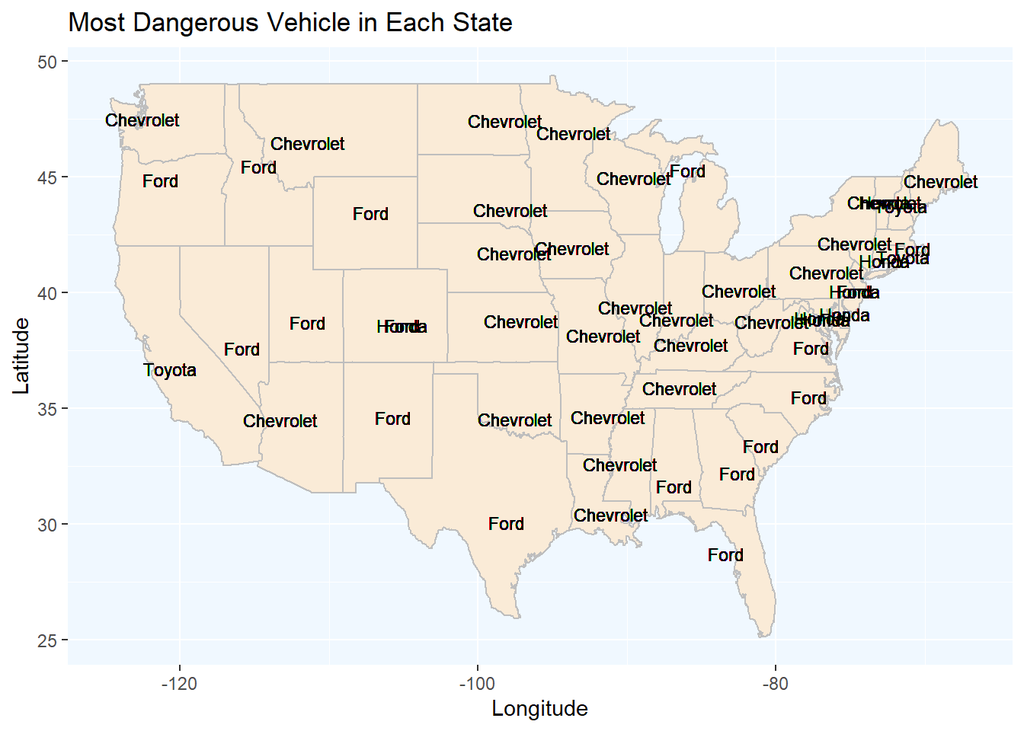

```r
GLCs <- readxl::read_xlsx("FRPP_GLC_-_United_StatesNov42021.xlsx")
GLCs$'State Code' <- as.numeric(GLCs$'State Code')
GLCs$'State Name' <- tolower(GLCs$'State Name')
GLCs$'City Code' <- as.numeric(GLCs$'City Code')
GLCs$'County Code' <- as.numeric(GLCs$'County Code')

states <- map_data('state')

state_df <- states %>%
   group_by(region) %>%
   summarise(mean(long, na.rm = TRUE), mean(lat, na.rm = TRUE))

state_df <- rename(state_df, long = 'mean(long, na.rm = TRUE)')
state_df <- rename(state_df, lat = 'mean(lat, na.rm = TRUE)')

state_df <- left_join(state_df, GLCs, by = c("region" = "State Name"))
state_df <- left_join(state_df, dangerous_vehicle_df, by = c("State Code" = "STATE"))

state_df$MAKE <- factor(state_df$MAKE, levels = c(12, 20, 49, 37),
 labels = c("Ford", "Chevrolet", "Toyota", "Honda"))

states %>%
   ggplot() + geom_polygon(aes(x=long, y=lat, group=group), color="grey", fill="antiquewhite") + geom_text(data=state_df, aes(long, lat, label = MAKE), color="black", size=3, check_overlap = FALSE) + ggtitle("Most Dangerous Vehicle in Each State") + theme(panel.background = element_rect(fill = "aliceblue"))+ xlab("Longitude") + ylab("Latitude")
```

4. Join the accident and person table (work out which variable(s) to use)

```r
acc_per <- inner_join(acc, per, by="ST_CASE")
```

5. Tally the number of accidents by day of the week (DAY_WEEK), hour of the day (HOUR) and gender (SEX). Visualize the results and explain what you find.

Based on the below graphic, males get into accidents about twice as much as women, even though some accidents do not directly involve a male causing the crash. The evening and early morning hours are the highest for both males and females. Evening crashes can result from many people driving during this time, such as evening rush hour, and morning could result from sleepiness or drunk driving. Both male and female-related crashes increase on the weekend from Friday-Sunday, but male crashes increase way more than female crashes. Around 5 am has the fewest accidents for both males and females since few people are driving during that time.

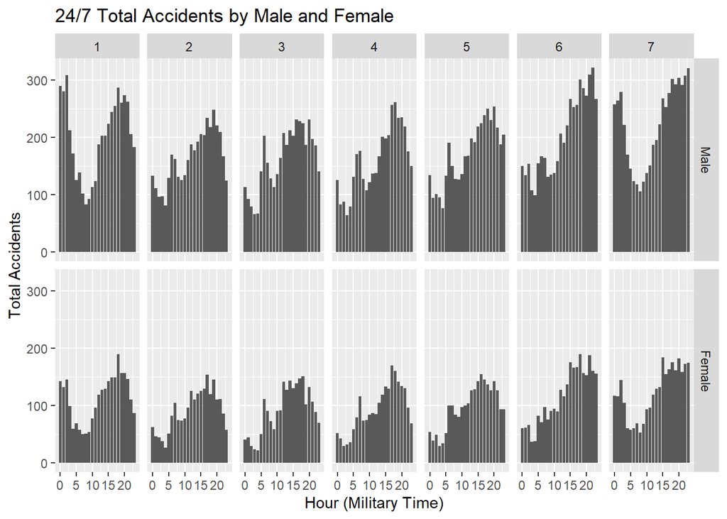

```r
total_accident_df <- acc_per %>%
   filter(SEX == 1 || SEX == 2) %>%
   group_by(ST_CASE, SEX) %>%
   summarise(mean(SEX))

total_accident_df <- rename(total_accident_df, total_sex = 'mean(SEX)')

total_accident_df <- total_accident_df %>%
   filter(SEX != 9 & SEX != 8)

total_accident_df$SEX <- factor(total_accident_df$SEX, levels = c(1, 2), labels = c("Male", "Female"))

accident_df <- total_accident_df %>%
   select(ST_CASE, SEX) %>%
   inner_join(acc, by='ST_CASE')

accident_df <- accident_df %>%
   filter(HOUR <= 24) %>%
   filter(DAY_WEEK != 9) %>%
   group_by(SEX, HOUR, DAY_WEEK) %>%
   summarise(n())

accident_df <- rename(accident_df, accidents = 'n()')

accident_df <- accident_df %>%
   arrange(desc(accidents))

ggplot(accident_df,aes(x=HOUR, y=accidents)) + geom_bar(stat='identity') + facet_grid(SEX~DAY_WEEK) + xlab("Hour (Military Time)") + ylab("Total Accidents") + ggtitle("24/7 Total Accidents by Male and Female")
```

6. Now plot a choropleth map of the number of deaths on a county level. Also explain what you find.

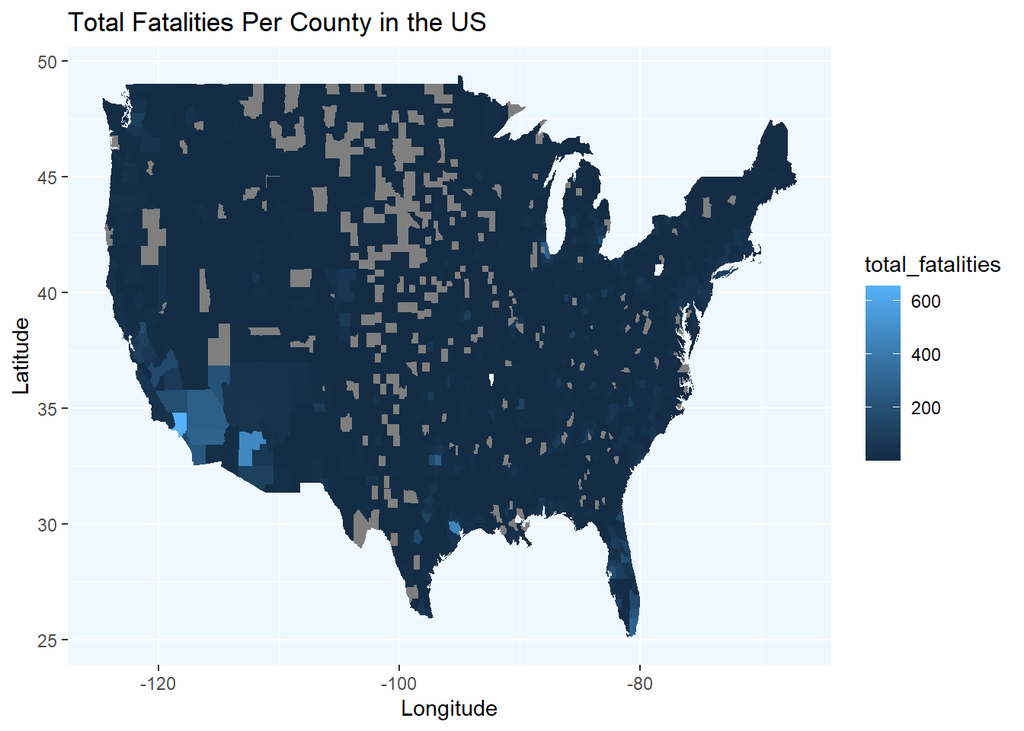

```r
fatalities <- acc[c("STATE", "COUNTY", "FATALS")]

fatalities <- fatalities %>%
   group_by(STATE, COUNTY) %>%
   summarize(sum(FATALS))
fatalities <- rename(fatalities, total_fatalities = 'sum(FATALS)')

fatalities <- fatalities %>%
   left_join(GLCs, by=c('COUNTY' = 'County Code', 'STATE' = 'State Code'))

fatalities <- unique(fatalities[c("State Name", "County Name", "total_fatalities")])

fatalities$`State Name` <- tolower(fatalities$`State Name`)
fatalities$`County Name` <- tolower(fatalities$`County Name`)

fatalities <- fatalities %>%
   right_join(map_data('county'), by=c('County Name' = 'subregion', 'State Name' = 'region'))

ggplot(fatalities, aes(long,lat, group=group, fill=total_fatalities)) + geom_polygon() + theme(panel.background = element_rect(fill = "aliceblue"))+ xlab("Longitude") + ylab("Latitude")+ggtitle("Total Fatalities Per County in the US")
```